# 7 Differential Expression Analysis II

Combined analysis with batch as a covariate

Published

October 28, 2025

## 7.1 Handling Batch-Treatment Confounding

When treatment is nested within batch, any observed difference between Cre-AAV and GFP could potentially be attributed to either true biological effects of the treatment or technical batch effects. However, unlike complete confounding, our design does allow for batch adjustment because GFP control samples exist in both batches.

A model with `~ batch + Sex + group` is mathematically valid: the batch effect can be estimated from GFP samples present in both batches, and the treatment effect is then estimated as the Cre-AAV versus GFP difference within Batch 2 after accounting for the batch effect.

## 7.2 Pre-filtering low count genes

Genes with very low read counts were excluded to minimize technical noise. After filtering for a minimum of 20 counts in at least five samples, approximately 19011 genes were retained for downstream analysis.

## 7.3 Differential expression analysis between Cre-AAV and GFP control groups in switch mice

Differential expression analysis was performed using DESeq2 with a design formula that explicitly modeled batch effects: `~ batch + Sex + group`. GFP Control was set as the reference level for treatment comparison.

Our design involves the same mice measured across batches (paired structure) nested within a batch-treatment confound. The ideal model would be a mixed-effects model with random effects: `Treatment + (1|MouseID) + (1|Batch)` DESeq2’s standard framework assumes all samples are independent and cannot model the correlation between repeated measurements of the same biological individual through random effects (e.g., mouse-specific baseline expression). Retaining both measurements would violate this independence assumption. While removing Batch 1 duplicates would resolve this, **we chose to collapse cross-batch measurements by averaging to preserve all sequencing data**. This approach treats each mouse as a single biological unit, though it reduces variance by averaging over real batch-to-batch measurement variability. While this reduces variance by averaging over real batch-to-batch variability (potentially anti-conservative), PCA showed minimal batch effects.

Significance thresholds were set at FDR < 0.05 and |log₂FC| > 1, with subsequent filtering to remove pseudogenes, unannotated loci, mitochondrial genes, and ribosomal protein genes.

### 7.3.1 Liver

In liver tissue from all mice (males and females combined), we identified 121 significantly differentially expressed genes between Cre-AAV and GFP control animals (FDR < 0.05, |log2FC| > 1).

##### **Diagnostic plots for the DE analysis**

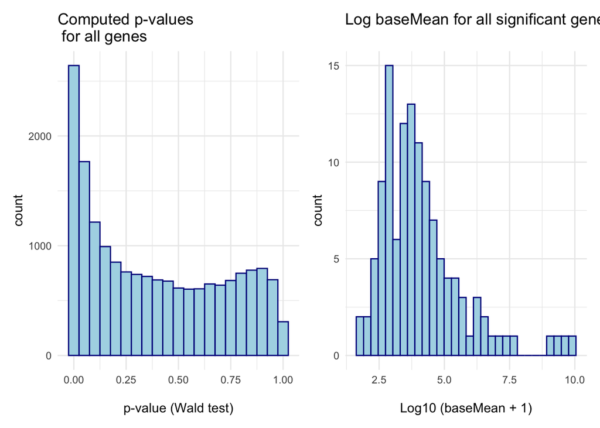

Diagnostic plots confirmed the validity of the analysis. The p-value distribution showed substantial enrichment for low p-values, indicating genuine differential expression rather than an all-noise result.

##### **Significantly differentially expressed genes in liver** Cre-AAV and GFP control (FDR < 0.05, |log2FC| > 1)

| gene | baseMean | log2FoldChange | padj |
| --- | --- | --- | --- |
| Rps26-ps1 | 18.84 | -6.60 | 0.00 |
| Vcp-rs | 65.58 | -2.35 | 0.00 |
| Rpl18-ps2 | 30.06 | -2.97 | 0.00 |
| Gm8566 | 108.75 | -2.14 | 0.00 |
| Gm10073 | 33.39 | -2.97 | 0.00 |
| Gm10263 | 18.29 | -4.10 | 0.00 |
| Rpl28-ps1 | 58.47 | -1.93 | 0.00 |
| Gstm2-ps1 | 53.61 | -2.97 | 0.00 |
| Gm45855 | 32.41 | -2.00 | 0.00 |
| Gm4332 | 37.02 | -2.56 | 0.00 |
| Gm11478 | 50.89 | -2.14 | 0.00 |
| Glo1-ps | 43.49 | -2.06 | 0.00 |
| Gm16437 | 14.46 | -3.16 | 0.00 |
| Gm13611 | 13.15 | -4.32 | 0.00 |
| Gm15163 | 39.33 | -1.89 | 0.00 |
| ENSMUSG00000143433 | 29.55 | -2.66 | 0.00 |
| Gm9816 | 17.24 | -2.16 | 0.00 |
| Gm13436 | 32.37 | -2.70 | 0.00 |
| Gm10221 | 38.13 | -2.11 | 0.00 |
| Gm4366 | 59.20 | -1.37 | 0.00 |
| Glns-ps1 | 29.01 | -2.54 | 0.00 |
| Ccdc148 | 79.22 | 1.29 | 0.00 |
| Eef2-ps2 | 25.88 | -2.81 | 0.00 |
| mt-Ts1 | 8.98 | -4.92 | 0.00 |
| Gm12481 | 52.96 | -6.89 | 0.00 |
| Lrp1 | 8579.16 | -1.08 | 0.00 |
| Gm11964 | 10.61 | -3.07 | 0.00 |
| Cox5b-ps | 37.20 | -1.81 | 0.00 |
| Ftl1-ps1 | 524.56 | -1.42 | 0.00 |
| Gm14586 | 43.58 | -2.27 | 0.00 |

[output cut: 91 more lines]

To focus on high-confidence, biologically interpretable results, we applied an additional filtering step to remove pseudogenes (*-ps, -rs*), unannotated loci (*Gm-, Rik, ENSMUS*), mitochondrial (*-mt*), and ribosomal (*-Rp*) genes. This yielded 26 high-confidence nuclear genes that were consistently dysregulated in response to Cre-mediated ApoE4→ApoE2 conversion in liver, after adjusting for both sex and batch effects.

| gene | baseMean | log2FoldChange | padj |
| --- | --- | --- | --- |
| Ccdc148 | 79.22 | 1.29 | 0.00 |
| Lrp1 | 8579.16 | -1.08 | 0.00 |
| Slc41a2 | 264.20 | -1.91 | 0.00 |
| Rgs4 | 54.71 | 1.19 | 0.00 |
| Eno1b | 38.52 | -2.73 | 0.00 |
| Mmp7 | 15.72 | 4.03 | 0.00 |
| Bnip3 | 12935.81 | 1.05 | 0.00 |
| Mov10 | 216.39 | -1.22 | 0.00 |
| Arg2 | 13.53 | 2.31 | 0.00 |
| Lncbate1 | 94.08 | 1.37 | 0.00 |
| Slc36a1 | 409.28 | -1.03 | 0.00 |
| Snhg3 | 225.84 | 1.56 | 0.00 |
| Myorg | 671.66 | -1.07 | 0.00 |
| Abca2 | 552.28 | -1.25 | 0.00 |
| Nhsl3 | 894.50 | -1.10 | 0.00 |
| Cd83 | 93.84 | 1.45 | 0.00 |
| C4b | 16639.92 | -1.04 | 0.00 |
| Mmp15 | 527.71 | -1.23 | 0.00 |
| Adrm1b | 37.12 | -1.71 | 0.01 |
| Ptprf | 2408.30 | -1.08 | 0.01 |
| Abca3 | 1162.54 | -1.05 | 0.01 |
| Sntg1 | 9.52 | 2.94 | 0.01 |
| Col1a1 | 50.22 | -1.25 | 0.01 |
| Sap18b | 38.87 | -1.28 | 0.01 |
| Mfhas1 | 318.41 | -1.03 | 0.01 |
| Fn1 | 19990.89 | -1.11 | 0.01 |

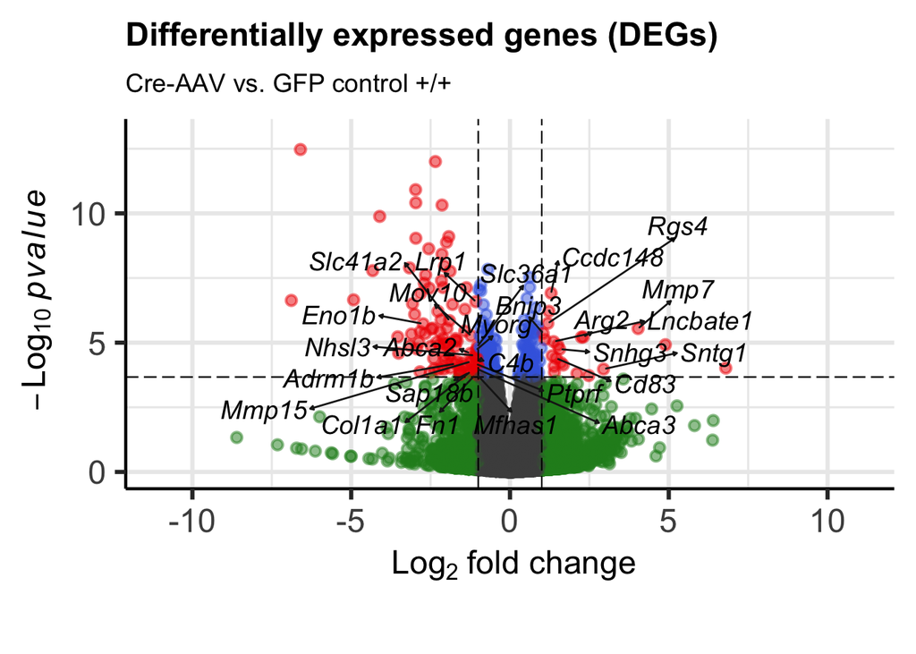

### 7.3.2 Brain

In brain tissue from all mice, we identified 150 significantly differentially expressed genes between Cre-AAV and GFP control animals using the same statistical approach and thresholds (FDR < 0.05, |log2FC| > 1).

##### **Diagnostic plots for the DE analysis**

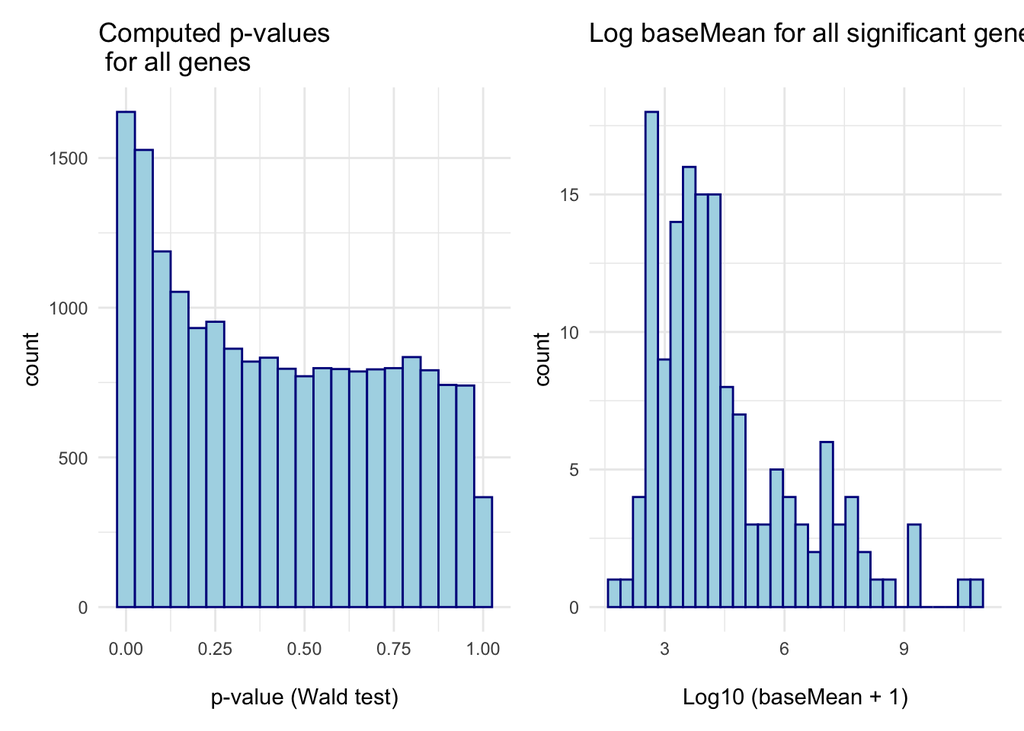

| gene | baseMean | log2FoldChange | padj |
| --- | --- | --- | --- |
| Gm15427 | 62.49 | -2.26 | 0.00 |
| Rpl35rt | 127.75 | -2.50 | 0.00 |
| Rpsa-ps10 | 72.78 | -2.05 | 0.00 |
| Cox5b-ps | 35.24 | -2.07 | 0.00 |
| Gm10288 | 97.74 | -1.96 | 0.00 |
| Rps16-ps2 | 55.97 | -2.35 | 0.00 |
| Rps6-ps4 | 115.70 | -1.24 | 0.00 |
| Rps19-ps6 | 38.23 | -2.75 | 0.00 |
| Gm4149 | 31.98 | -2.53 | 0.00 |
| Rps26-ps1 | 14.16 | -5.64 | 0.00 |
| Rps3a2 | 68.28 | -1.92 | 0.00 |
| 4632415L05Rik | 14.57 | -5.24 | 0.00 |
| Rpl19-ps11 | 99.78 | -1.79 | 0.00 |
| Gm10073 | 41.80 | -2.71 | 0.00 |
| Rpl17-ps10 | 78.73 | -1.81 | 0.00 |
| Gm6560 | 72.20 | -1.37 | 0.00 |
| ENSMUSG00000136525 | 49795.59 | 0.84 | 0.00 |
| Gm11478 | 43.76 | -2.41 | 0.00 |
| Rps18-ps5 | 21.26 | -3.69 | 0.00 |
| Rpl14-ps1 | 56.17 | -1.53 | 0.00 |
| Rpl17-ps3 | 50.93 | -2.15 | 0.00 |
| ENSMUSG00000121793 | 81.80 | -2.33 | 0.00 |
| Eno1b | 46.81 | -2.12 | 0.00 |
| Gm13456 | 187.81 | -1.36 | 0.00 |
| Rpl3-ps1 | 182.80 | -1.08 | 0.00 |
| Rps18-ps6 | 37.32 | -2.34 | 0.00 |
| Rpl23a-ps3 | 35.90 | -1.85 | 0.00 |
| Gm4332 | 27.77 | -2.94 | 0.00 |
| Rps13-ps1 | 30.42 | -2.42 | 0.00 |
| Gm9385 | 45.24 | -1.82 | 0.00 |

[output cut: 120 more lines]

After applying the same filtering criteria to exclude pseudogenes, unannotated loci, mitochondrial genes, and ribosomal protein genes, we retained 5 high-confidence nuclear genes that showed consistent dysregulation in brain tissue following Cre-mediated ApoE4→ApoE2 conversion, adjusted for batch and sex.

| gene | baseMean | log2FoldChange | padj |
| --- | --- | --- | --- |
| Eno1b | 46.81 | -2.12 | 0.00 |
| Uba52rt | 148.07 | -1.35 | 0.00 |
| Aldoart1 | 15.29 | -2.54 | 0.00 |
| Cdr1 | 119.55 | 1.24 | 0.01 |
| Sap18b | 30.52 | -1.37 | 0.01 |

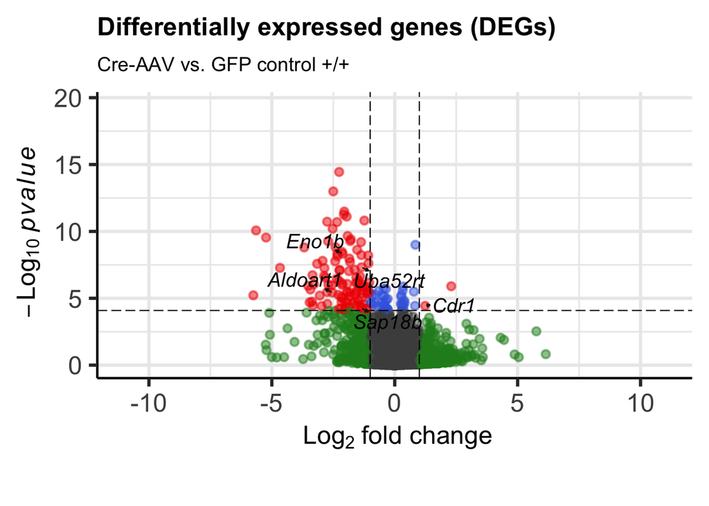

### 7.3.3 Common DEGs in liver and brain

To identify core molecular responses to ApoE isoform conversion that occur independently of tissue context, we intersected the lists of high-confidence DEGs from liver and brain. In the batch-adjusted analysis, only 2 genes were significantly differentially expressed in both tissues:

```
Eno1b, Sap18b
```